# More network analysis with igraph and Cytoscape

Keiichiro Ono

6/17/2015

## Basic Workflow 3: Visual Styles

by [Kazuhiro Takemoto](https://sites.google.com/site/kztakemoto/r-seminar-on-igraph---supplementary-information)*

Updated by [Keiichiro Ono](http://keiono.github.io/)

(The original tutorial was developed by Dr. Takemoto, and updated by Keiichiro Ono for cy-rest.)

[figure not shown]

## Introduction

Welcome to part 3 of the R tutorial. In this section, you will learn how to use more advanced igraph features to analyse your networks.

```r
# Basic setup
library(igraph)
library(RJSONIO)
library(httr)
library(RColorBrewer)
source('../utility/cytoscape_util.R')
```

## Loading Network and Data Table

Loading and mapping data onto networks is a bit complicated in Cytoscape. Let’s do it in R instead.

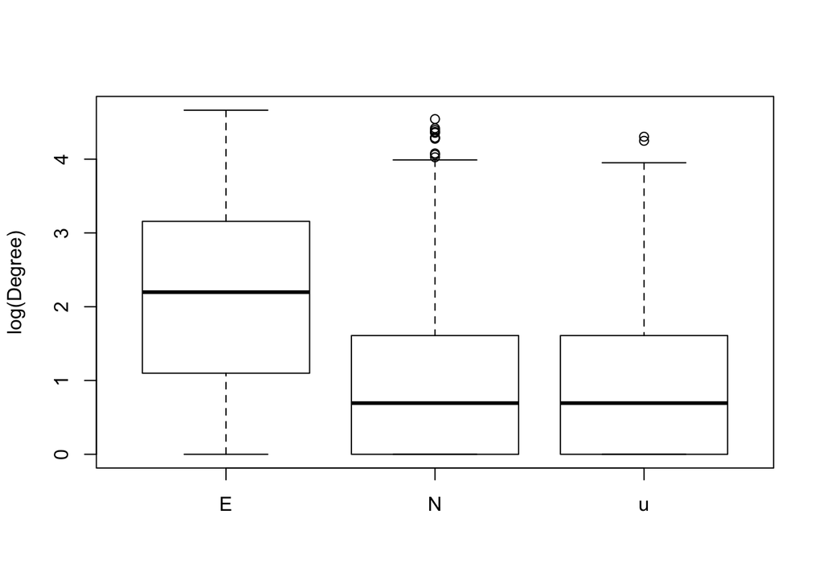

```r
# Read network from edge list file
df <- read.table("../data/ecoli_ppi_Hu_etal_2009.txt")

# Create undirected igraph object from data frame
g <- graph.data.frame(df, directed=F)

# Make this network a bit more biologist-friendly by adding some more annotations.
#   Original table is from: http://www.ecogene.org/?q=ecodownload/dbtable

annotations <-read.delim("../data/EcoData061715-172714.txt",header=T,  quote = NULL)
column.names <- colnames(annotations)
filtered <- annotations[1:(length(column.names)-1)]

V(g)$symbol <- as.character(filtered$Gene[match(V(g)$name, filtered$b.)])
V(g)$description <- as.character(filtered$Description[match(V(g)$name, filtered$b.)])
V(g)$func <- as.character(filtered$Function[match(V(g)$name, filtered$b.)])
V(g)$protein <- as.character(filtered$Protein[match(V(g)$name, filtered$b.)])
V(g)$eg <- as.character(filtered$EG[match(V(g)$name, filtered$b.)])
V(g)$sp <- as.character(filtered$SP[match(V(g)$name, filtered$b.)])

# Read essentiality table
ess<-read.table("../data/ecoli_proteins_essentiality_Baba2006MSB.txt", header=T)

# Basic graph analysis: Calculate degree of nodes
degrees <- degree(g)
V(g)$degree <- degrees


# Find intersection of these two data sets
targets <- intersect(ess$gene, V(g)$name)

# And create subset from the original table
ess.selected <- subset(ess, is.element(ess$gene, targets)==T & duplicated(ess$gene)==F)
ess.selected.ord <- ess.selected[order(ess.selected$gene),]

# Add it as attribute
V(g)$ess <- as.character(ess.selected$essential[match(V(g)$name, ess.selected$gene)])

# Plot degrees
degrees.selected <- subset(degrees, is.element(names(degrees), targets)==T)
degrees.selected.ord <- degrees.selected[order(names(degrees.selected))]

boxplot(log(degrees.selected.ord)~ess.selected.ord$ess, ylab="log(Degree)")
```

## Visualize the result in Cytoscape

Boxplot is a great way to see the overall trend in the network, but it is more helpful if you can see the result in a network diagram. You can do it by creating custom style for Cytoscape, that has mappings from degree to size, and from essintiality to colors.

```r
# Name of this new style
style.name = "EssentialityAndDegree"

# Delete the existing style for fresh start...
style.url = paste(base.url, "styles", sep="/")
style.delete.url = paste(style.url, style.name, sep="/")
DELETE(url=style.delete.url)
```

```
## Response [http://localhost:1234/v1/styles/EssentialityAndDegree]
##   Date: 2015-06-17 16:08
##   Status: 204
##   Content-Type: <unknown>
## <EMPTY BODY>
```

```r
# Define default values
def.node.color <- list(
  visualProperty = "NODE_FILL_COLOR",
  value = "#eeeeee"
)

def.node.size <- list(
  visualProperty = "NODE_SIZE",
  value = 10
)

def.node.border.width <- list(
  visualProperty = "NODE_BORDER_WIDTH",
  value = 0
)

def.edge.width <- list(
  visualProperty = "EDGE_WIDTH",
  value = 1
)

def.edge.color <- list(
  visualProperty = "EDGE_STROKE_UNSELECTED_PAINT",
  value = "#aaaaaa"
)

def.edge.transparency = list(
  visualProperty="EDGE_TRANSPARENCY",
  value = 50
)

def.node.transparency = list(
  visualProperty="NODE_TRANSPARENCY",
  value = 200
)

def.node.label.transparency = list(
  visualProperty="NODE_LABEL_TRANSPARENCY",
  value = 100
)

defaults <- list(def.node.color, def.node.size,
                 def.edge.color, def.node.border.width,
                 def.edge.width, def.node.transparency, def.node.label.transparency,
                 def.edge.transparency)
```

### Mapping Definition

- Node Degree to Node Size
- Essentiality to Node Color
- Use Gene symbol as label

```r
# Visual Mappings
mappings = list()

colors <- brewer.pal(3,"Dark2")
essvals <- c("E", "N", "u")
discrete.mappings = list()
for(i in 1:length(colors)) {
  discrete.mappings[[i]] <- list(key = essvals[i], value = colors[i])
}

node.color = list(
  mappingType="discrete",
  mappingColumn="ess",
  mappingColumnType="String",
  visualProperty="NODE_FILL_COLOR",
  map = discrete.mappings
)

node.label = list(
  mappingType="passthrough",
  mappingColumn="symbol",
  mappingColumnType="String",
  visualProperty="NODE_LABEL"
)
# Node Size Mapping
min.degree = min(V(g)$degree)
max.degree = max(V(g)$degree)

point1 = list(
  value=min.degree,
  lesser= "10.0",
  equal="10.0",
  greater="10.0"
)

point2 = list(
  value=max.degree,
  lesser= "100.0",
  equal="100.0",
  greater="100.0"
)

node.size.continuous.points = list(point1, point2)

node.size = list(
  mappingType="continuous",
  mappingColumn="degree",
  mappingColumnType="Double",
  visualProperty="NODE_SIZE",
  points = node.size.continuous.points
)

mappings = list(node.color, node.label, node.size)

style <- list(title=style.name, defaults = defaults, mappings = mappings)
style.JSON <- toJSON(style)

POST(url=style.url, body=style.JSON, encode = "json")
```

```
## Response [http://localhost:1234/v1/styles]
##   Date: 2015-06-17 16:08
##   Status: 201
##   Content-Type: application/json
##   Size: 34 B
```

## Layout and Visualization in Cytoscape

Once everything is ready, send it to Cytoscape. This code executes edge bundling, too.

```r
cygraph <- toCytoscape(g)
```

```
## [1] 1000
## [1] 1000
## [1] 2000
## [1] 3000
## [1] 4000
## [1] 5000
## [1] "Done.  To json Start..."
```

```r
network.url = paste(base.url, "networks", sep="/")
res <- POST(url=network.url, body=cygraph, encode="json")

# Extract SUID of the new network
network.suid = unname(fromJSON(rawToChar(res$content)))

# Apply style
apply.style.url = paste(base.url, "apply/styles", style.name , toString(network.suid), sep="/")
GET(apply.style.url)
```

```
## Response [http://localhost:1234/v1/apply/styles/EssentialityAndDegree/46588]
##   Date: 2015-06-17 16:08
##   Status: 200
##   Content-Type: application/json
##   Size: 35 B
```

```r
# Apply force-directed layout

# Tweak Layout parameters
layout.params = list(
  name="unweighted",
  value=TRUE
)
layout.params.url = paste(base.url, "apply/layouts/kamada-kawai/parameters", sep="/")
PUT(layout.params.url, body=toJSON(list(layout.params)), encode = "json")
```

```
## Response [http://localhost:1234/v1/apply/layouts/kamada-kawai/parameters]
##   Date: 2015-06-17 16:08
##   Status: 200
##   Content-Type: application/json
## <EMPTY BODY>
```

```r
apply.layout.url = paste(base.url, "apply/layouts/kamada-kawai", toString(network.suid), sep="/")
GET(apply.layout.url)
```

```
## Response [http://localhost:1234/v1/apply/layouts/kamada-kawai/46588]
##   Date: 2015-06-17 16:09
##   Status: 200
##   Content-Type: application/json
##   Size: 30 B
```

```r
# Perform Edge Bundling
apply.bundling.url = paste(base.url, "apply/edgebundling", toString(network.suid), sep="/")
GET(apply.bundling.url)
```

```
## Response [http://localhost:1234/v1/apply/edgebundling/46588]
##   Date: 2015-06-17 16:09
##   Status: 200
##   Content-Type: application/json
##   Size: 36 B
```

```r
# Toggle graphics details
lod.url = paste(base.url, "ui/lod", sep="/")
PUT(lod.url)
```

```
## Response [http://localhost:1234/v1/ui/lod]
##   Date: 2015-06-17 16:09
##   Status: 200
##   Content-Type: application/json
##   Size: 48 B
```

## Final Result

Fater a minuite or so, you can see something like this in the Cytoscape window:

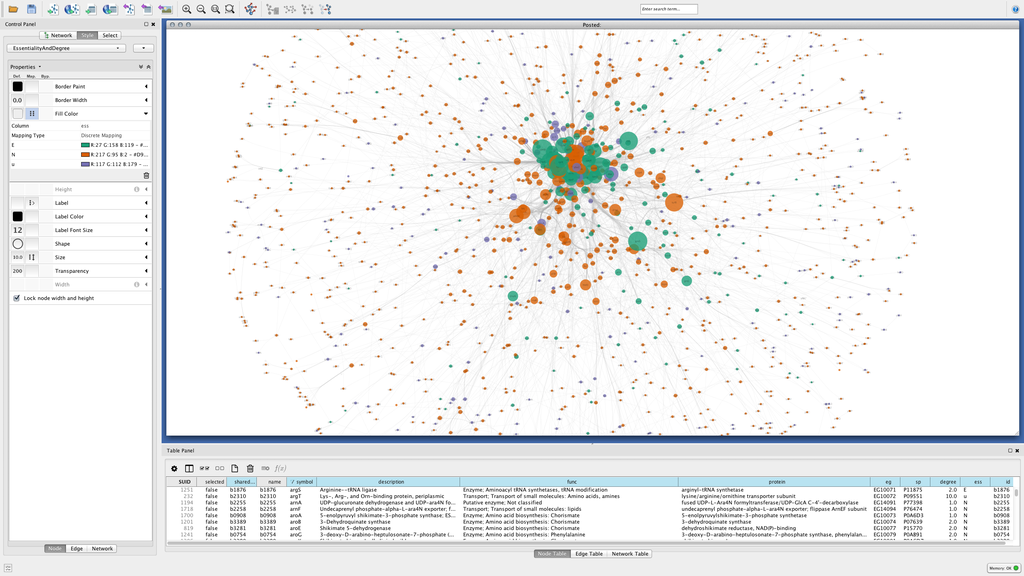

Now you can visually see the trend, that is, **E** nodes tend to have higher degrees.